# Abundance of mountain yellow-legged frog across the Sierra Lakes

Quin Smith

1/18/2021

### Introduction:

This visual analysis with associated R-markdown file explores abundance data of mountain yellow-legged frogs (Rana muscosa) recorded by R.A. Knapp et al. and the Sierra Lakes Inventory Project. The data was collected between 1995 and 2002 across a study area containing “over 8,000 lentic water bodies in the southern Sierra Nevada, including lakes, ponds, marshes, and meadows” (Environmental Data Initiative Repository).

### Section 1:

A line graph of total mountain yellow-legged frog (Rana muscosa) count each year across all water bodies, by life stage excluding the ‘EggMass’ level.

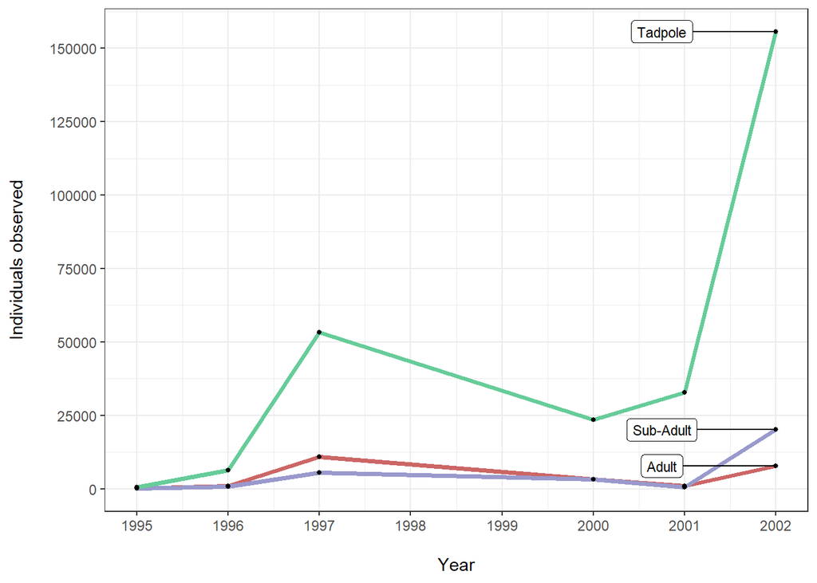

```r
#read in/wrangle data to only include mountain yellow-legged frogs (RAMU) across all water bodies by life stage and year, excluding 'EggMass'
frogs <- read_excel(here("data", "sierra_amphibians.xlsx"))

ramu_frogs <- frogs %>%
  mutate(survey_date = ymd(survey_date)) %>%
  mutate(year = year(survey_date)) %>%
  filter(amphibian_species == "RAMU" & amphibian_life_stage != "EggMass") %>%
  group_by(amphibian_life_stage, year) %>%
  summarize(n = sum(amphibian_number, na.rm = TRUE))

#ggrepel label
gg_labeller <- ramu_frogs %>%
  mutate(gg_lab = case_when(
    year == 2002 & amphibian_life_stage == "Adult" ~ "Adult",
    year == 2002 & amphibian_life_stage == "SubAdult" ~ "Sub-Adult",
    year == 2002 & amphibian_life_stage == "Tadpole" ~ "Tadpole"
  ))

#graph of number of individuals observed given conditions above
fig_palette <- c("#009E73", "#0072B2", "#D55E00")
fig_palette2 <- c("#CC6666", "#9999CC", "#66CC99")

#Create line graph: number observations of RAMU per year over all water bodies by life-stage
ramu_graph <- ramu_frogs %>%
  ggplot(aes(x = year, y = n)) +
  geom_path(aes(color = amphibian_life_stage), size = 1.25) +
  geom_point(size = 1) +
  scale_color_manual(values = fig_palette2) +
  labs(x = "\nYear", y = "Individuals observed\n", color = "Life Stage" ) +
  geom_label_repel(data = gg_labeller, aes(label = gg_lab),
                   nudge_x = -1.25,
                   size = 3,
                   na.rm = TRUE) +
  theme_bw() +
  theme(legend.position = "none") +
  scale_y_continuous(breaks = seq(0, 185000, 25000)) +
  scale_x_continuous(breaks = seq(1995, 2002, 1))

ramu_graph
```

### Section 2:

A column graph containing total counts (over all years of the study) of combined adult and subadult endangered mountain yellow-legged frogs (Rana muscosa) observed in the 5 lakes with the greatest total observed counts.

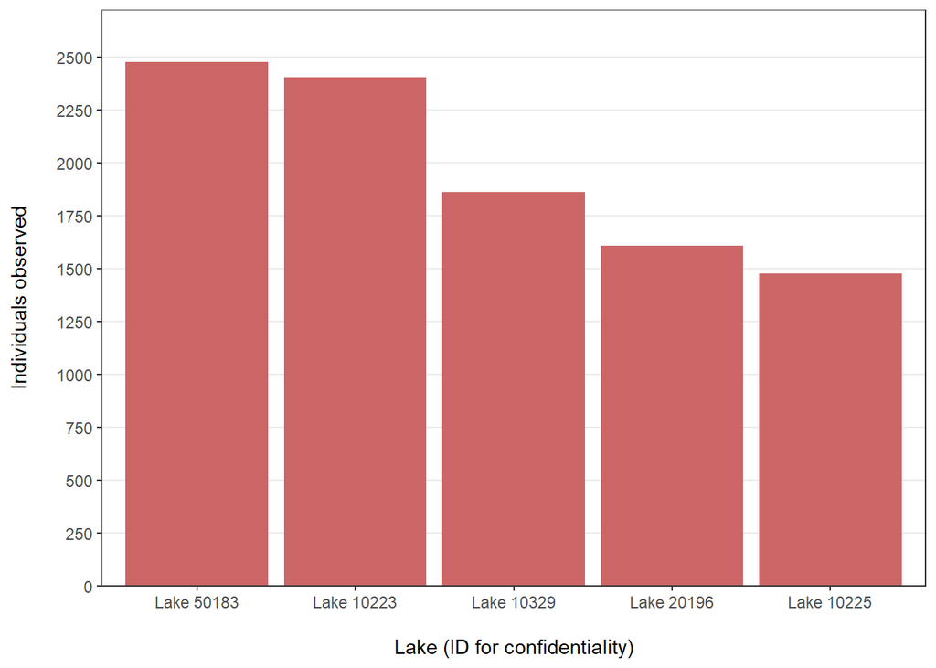

```r
#wrangle data to create a subset of total counts of observed adult and subadult RAMU by lake, 5 top lakes (in observations)
ramu_lake <- frogs %>%
  mutate(lake_id = paste("Lake", frogs$lake_id, sep = " ")) %>%
  filter(amphibian_species == "RAMU" &
           amphibian_life_stage %in% c("SubAdult", "Adult")) %>%
  group_by(lake_id) %>%
  summarize(n = sum(amphibian_number)) %>%
  mutate(lake_id = fct_reorder(lake_id, n)) %>%
  slice_max(order_by = n, n = 5)

#column graph with 5 top lakes
lake_graph <- ggplot(data = ramu_lake, aes(x = reorder(lake_id, -n), y = n)) +
  geom_col(fill = "#CC6666") +
  labs(x = "\nLake (ID for confidentiality)", y = "Individuals observed\n") +
  scale_y_continuous(breaks = seq(0, 2500, 250), expand = expansion(mult = c(0, .1))) +
  theme_bw() +
  removeGridX()

lake_graph
```

### Section 3:

A compound figure containing the graphs from sections 1 and 2.

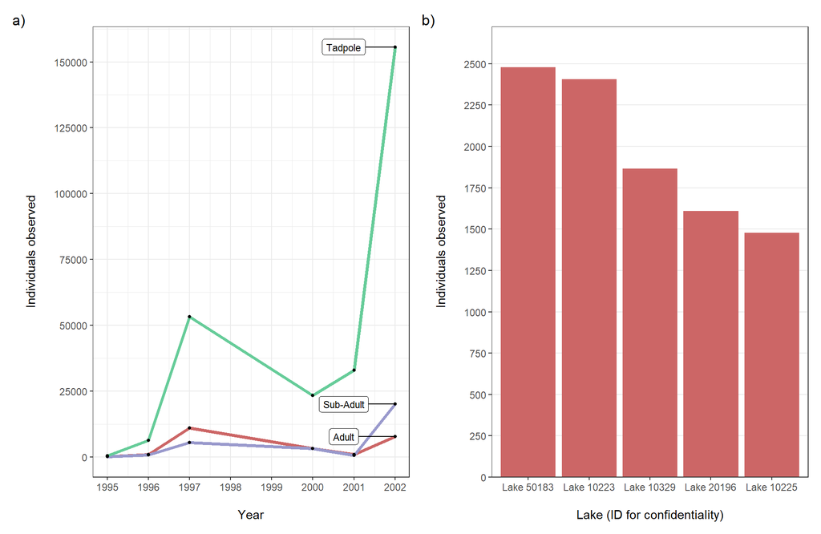

```r
#combine graphs with patchwork
comp_graph <- ramu_graph + lake_graph +
  plot_annotation(tag_levels = 'a',
                  tag_suffix = ")")

comp_graph
```

### Data Citation:

Knapp, R.A., C. Pavelka, E.E. Hegeman, and T.C. Smith. 2020. The Sierra Lakes Inventory Project: Non-Native fish and community composition of lakes and ponds in the Sierra Nevada, California ver 2. Environmental Data Initiative. https://doi.org/10.6073/pasta/d835832d7fd00d9e4466e44eea87fab3